# Homework_11.rmd

Isaac Racine

3/31/2021

# Question 1

## Organizing data

I only have one data set of this data so I will have to simulate more datasets for batch processing. I will not split the data into categorical groups while simulating random data sets because want to test if the amount of above ground biomass is happening by chance or not.

```r
# Isaac Racine
# HW 11
# 31 Mar 2021
#------------------------------------------------
library(ggplot2)
library(tidyverse)
#https://datadryad.org/stash/dataset/doi:10.5061/dryad.82vr4
#where I got my data

z <- read.table("AbovegroundData.csv",header=TRUE,sep=",", stringsAsFactors=FALSE)

#add ID column, index age and biomass to new dataframe
z <- data.frame(1:nrow(z),z$Age, z$AGB)
names(z) <- list("ID","Age","Biomass")


#change Age's with OG to 200
#OG meant they were too old to detemine an age
#we will put in age of 200
z <- z %>%
  mutate(Age = str_replace(Age, "OG", "200"))



#change age from char to int
z$Age <- as.numeric(as.character(z$Age))

#see summary
summary(z)
```

```
##        ID              Age            Biomass
##  Min.   :   1.0   Min.   :  0.00   Min.   :   0.00
##  1st Qu.: 334.2   1st Qu.: 10.00   1st Qu.:  43.41
##  Median : 667.5   Median : 20.00   Median :  98.31
##  Mean   : 667.5   Mean   : 42.65   Mean   : 141.51
##  3rd Qu.:1000.8   3rd Qu.: 40.00   3rd Qu.: 176.67
##  Max.   :1334.0   Max.   :200.00   Max.   :3655.20
```

```r
#don't split the data into treatments
unsplit_df <- z

#find values needed for gamma
unsplit_num <-(length(unsplit_df))
unsplit_mean <- mean(unsplit_df$Biomass)
unsplit_var <- var(unsplit_df$Biomass)


#-------------- Creating Simulated (Radnom) Data --------------
#Since the data is simulated all treatment groups will get the same parameters to see if by chance this could be the case
#for gamma distribution must determine shape and scale
unsplit_shpae <- (unsplit_mean^2) / unsplit_var
print(unsplit_shpae) #will be needed for later function
```

```
## [1] 0.5731653
```

```r
unsplit_scale <- unsplit_var/unsplit_mean
print(unsplit_scale) #will be needed for later function
```

```
## [1] 246.8969
```

## Building Functions

I built functions to simulate 100 of random samples of random sizes. I did make the minimum sample size be 500 due to the length of the orginal dataframe being over 1000 entries long. Also the regStats function calculates the p-value and F-value of an ANOVA.

```r
#-------------- Make functions for simulating multiple dataframes ---------------

#use dim to find length of dataframe
#this will be used in the filebuilder function
#to determine how many rows hould be made
dim(z)
```

```
## [1] 1334    3
```

```r
##################################################
# function: FileBuilder
# create a set of random files for regression
# input: fileN = number of files to create
#       : fileFolder = name of folder for random files
#       : fileSize = c(min,max) number of rows in file
#       : fileNA = number on average of NA values per column
# output: set of random files
#-------------------------------------------------
FileBuilder <- function(fileN=100,
                        fileFolder="AbovegroundRandFile/",
                        fileSize=c(500,1334),
                        fileNA=3){
  for (i in seq_len(fileN)) {
    fileLength <- sample(fileSize[1]:fileSize[2],size=1) # get number of rows
    varX <- sample(c("Young", "Middle", "Old"), fileLength, replace = TRUE) # create random x
    varY <- rgamma(fileLength, shape = 0.5731653, scale = 246.8969) # create random Y
    dF <- data.frame(varX,varY) # bind into a data frame
    # create label for file name with padded zeroes
    fileLabel <- paste(fileFolder,
                       "ranFile",
                       formatC(i,
                               width=3,
                               format="d",
                               flag="0"),
                       ".csv",sep="")

    # set up data file and incorporate time stamp and minimal metadata
    write.table(cat("# Simulated random data file for batch processing using aboveground biomasss data","\n",
                    "# timestamp: ",as.character(Sys.time()),"\n",
                    "# ISR","\n",
                    "# ------------------------", "\n",
                    "\n",
                    file=fileLabel,
                    row.names="",
                    col.names="",
                    sep=""))

    # now add the data frame
    write.table(x=dF,
                file=fileLabel,
                sep=",",
                row.names=FALSE,
                append=TRUE)


  }
}

#---------------------------------------
# FUNCTION regStats
# description: runs ANOVA
# inputs: 2-column data frame
# outputs: F-stat, p-value
########################################
regStats <- function(d = NULL) {

  #d$Biomass <-unlist(d$Biomass)

  . <- aov(d[,2] ~ d[,1], data = d)
  #. <- summary(.)
  statList <- list(p_value = summary(.)[[1]][1,5],
                   F_value = summary(.)[[1]][1,4])
# function body

return(statList)

} # end of regStats
#--------------------------------------
```

## Doing the batch processing

The following actually simulates batch processing by creating 100 of randomly generated samples of random sizes. The gamma distribution used to simulate the random data was not split by treatment group, becuase under the null hypothesis there should be no differences of means.

```r
#-------------- Summary of all Samples ---------------


library(TeachingDemos)
char2seed("Freezing March")

#--------------------------------------------
# Global variables
fileFolder <- "AbovegroundRandFile/"
nFiles <- 100
fileOut <- "StatsSummary.csv"
#--------------------------------------------

# Create 100 random data sets
FileBuilder(fileN=nFiles)
```

[output not shown]

[output not shown]

[output not shown]

[output not shown]

[output not shown]

[output not shown]

[output not shown]

[output not shown]

[output not shown]

[output not shown]

[output not shown]

[output not shown]

[output not shown]

[output not shown]

[output not shown]

[output not shown]

[output not shown]

[output not shown]

[output not shown]

[output not shown]

[output not shown]

[output not shown]

[output not shown]

[output not shown]

[output not shown]

[output not shown]

[output not shown]

[output not shown]

[output not shown]

[output not shown]

[output not shown]

[output not shown]

[output not shown]

[output not shown]

[output not shown]

[output not shown]

[output not shown]

[output not shown]

[output not shown]

[output not shown]

[output not shown]

[output not shown]

[output not shown]

[output not shown]

[output not shown]

[output not shown]

[output not shown]

[output not shown]

[output not shown]

[output not shown]

[output not shown]

[output not shown]

[output not shown]

[output not shown]

[output not shown]

[output not shown]

[output not shown]

[output not shown]

[output not shown]

[output not shown]

[output not shown]

[output not shown]

[output not shown]

[output not shown]

[output not shown]

[output not shown]

[output not shown]

[output not shown]

[output not shown]

[output not shown]

[output not shown]

[output not shown]

[output not shown]

[output not shown]

[output not shown]

[output not shown]

[output not shown]

[output not shown]

[output not shown]

[output not shown]

[output not shown]

[output not shown]

[output not shown]

[output not shown]

[output not shown]

[output not shown]

[output not shown]

[output not shown]

[output not shown]

[output not shown]

[output not shown]

[output not shown]

[output not shown]

[output not shown]

[output not shown]

[output not shown]

[output not shown]

[output not shown]

[output not shown]

[output not shown]

```r
fileNames <- list.files(path=fileFolder)


# Create data frame to hold file summary statistics
ID <- seq_along(fileNames)
fileName <- fileNames
p_val <- rep(NA,nFiles)
F_val <- rep(NA,nFiles)


statsOut <- data.frame(ID,fileName,p_val,F_val)
data <- read.table(file=paste(fileFolder,fileNames[1],sep=""),
                   sep=",",
                   header=TRUE)

# batch process by looping through individual files
for (i in seq_along(fileNames)) {
  data <- read.table(file=paste(fileFolder,fileNames[i],sep=""),
                     sep=",",
                     header=TRUE) # read in next data file

  dClean <- data[complete.cases(data),] # get clean cases

  . <- regStats(dClean) # pull regression stats from clean file
  statsOut[i,3:4] <- unlist(.) # unlist, copy into last 3 columns

}
# set up output file and incorporate time stamp and minimal metadata
write.table(cat("# Summary stats for ",
                "batch processing of regression models","\n",
                "# timestamp: ",as.character(Sys.time()),"\n",
                "# ISR","\n",
                "# ------------------------", "\n",
                "\n",
                file=fileOut,
                row.names="",
                col.names="",
                sep=""))
```

```
## ""
```

```r
# now add the data frame
write.table(x=statsOut,
            file=fileOut,
            row.names=FALSE,
            col.names=TRUE,
            sep=",",
            append=TRUE)
print(statsOut)
```

```
##      ID       fileName      p_val       F_val
## 1     1 ranFile001.csv 0.68243012 0.382259240
## 2     2 ranFile002.csv 0.59605044 0.517640353
## 3     3 ranFile003.csv 0.54496887 0.607407819
## 4     4 ranFile004.csv 0.74370273 0.296204956
## 5     5 ranFile005.csv 0.38236926 0.962167759
## 6     6 ranFile006.csv 0.78557425 0.241398674
## 7     7 ranFile007.csv 0.22592971 1.489452117
## 8     8 ranFile008.csv 0.29886894 1.209467813
## 9     9 ranFile009.csv 0.91581881 0.087945572
## 10   10 ranFile010.csv 0.71389479 0.337191056
## 11   11 ranFile011.csv 0.58868357 0.530141015
## 12   12 ranFile012.csv 0.25740961 1.359027114
## 13   13 ranFile013.csv 0.55852733 0.582920565
## 14   14 ranFile014.csv 0.62493623 0.470351586
```

[output cut: 86 more lines]

## Comparing Batch to Actual Results

The following will display graphs that were done in randomization tests. These plots show where the observed p_value and f_values are compared to those of the 100 simulated samples.

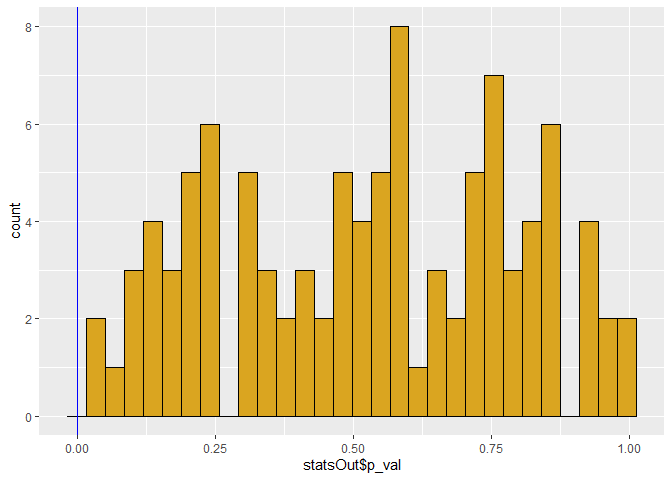

```r
#-------------- Make Bootstrap PLot ---------------
z_p_val <- 2.95e-8
# Know this from HW 8


p1 <- ggplot(data = statsOut, mapping = aes(x = statsOut$p_val))
p1 + geom_histogram(mapping = aes(fill = I("goldenrod"),
                                  color = I("black"))) +
  geom_vline(aes(xintercept = z_p_val, col = "blue"))
```

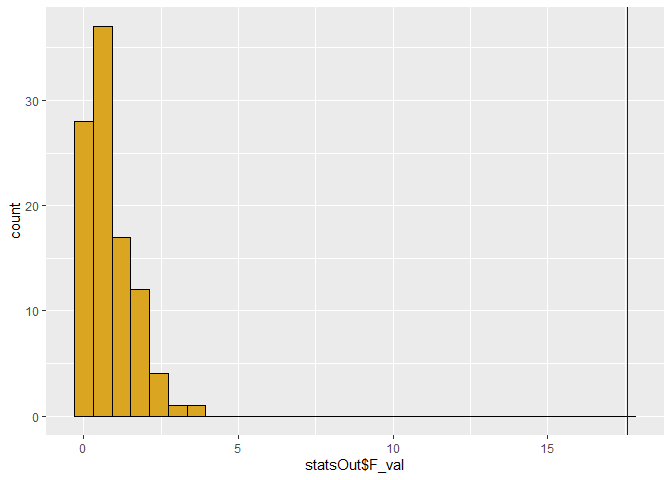

```r
z_f_val <- 17.57

p2 <- ggplot(data = statsOut, mapping = aes(x =statsOut$F_val))
p2 + geom_histogram(mapping = aes(fill = I("goldenrod"),
                                  color = I("black"))) +
  geom_vline(aes(xintercept = z_f_val, col = "blue"))
```

As can be seen from the plots the original data has very strong evidence that there is a larger amount of above ground abundance based of the age of forest plot. This could not be determined from this homework alone, but rather from all of the homeworks where above ground biomass data was used.